# Comparison between R and python functions for prediction

Author

Ana Afonso Silva

Published

August 30, 2024

**Make test data from Ember EU data since 2019 with demand**

```r
EU_subset <- read_csv("monthly_full_release_long_format-4_20240826.csv",
                      show_col_types = FALSE) %>%
  filter(Variable %in% 'Demand', EU == 1, Date >= "2019-01-01") %>%
  select(Area, Date, Value)

# EU_subset %>%
#   write_delim("/Users/acas/Dropbox/BFF/projects/QuaterlyReports/Ember_API_python/EU_subset.txt",  col_names = TRUE, quote = "none", delim = "\t")
```

## Run predictions with python models

- ARIMA (pmdarima): Uses auto_arima with seasonal=True and m=12 for automatic model selection, handling seasonality with a 12-month cycle.
- Prophet: Employs default settings, which include automatic changepoint detection and yearly seasonality.
- ARIMA (scikit-learn): Implements a custom ARIMA estimator with fixed order (1,1,1), suitable for integration with scikit-learn’s API.

```python
## code developed with cursor
## ## to install packages: /Users/acas/miniconda3/envs/r-reticulate/bin/pip install fbprophet

import sys
import os
import pandas as pd
import numpy as np
from pmdarima import auto_arima
from prophet import Prophet
```

```
Importing plotly failed. Interactive plots will not work.
```

```python
from sklearn.base import BaseEstimator, RegressorMixin
from statsmodels.tsa.arima.model import ARIMA as StatsmodelsARIMA
from sklearn.metrics import r2_score
import warnings
import traceback
import logging

logger = logging.getLogger('cmdstanpy')
logger.addHandler(logging.NullHandler())
logger.propagate = False
logger.setLevel(logging.CRITICAL)
logging.getLogger('prophet').setLevel(logging.CRITICAL)


# Suppress warnings
warnings.filterwarnings("ignore")

### load r object
dfr = pd.DataFrame(r.EU_subset)
dfr['Date'] = pd.to_datetime(dfr['Date'])

df = dfr

# print(dfr)
# print(dfr.dtypes)

# # Load the data - if needed to load locally
# df = pd.read_csv('/Users/acas/Dropbox/BFF/projects/QuaterlyReports/Ember_API_python/EU_subset.txt',
#                  sep='\t', parse_dates=['Date'])
# print(df)
# print(df.dtypes)

# After loading, let's resample the data to monthly frequency
df['Date'] = pd.to_datetime(df['Date']).dt.to_period('M').dt.to_timestamp()
df = df.groupby(['Date', 'Area'])['Value'].mean().reset_index()

# Set the date range for training and testing
train_end = '2023-05-01'
test_start = '2023-06-01'
test_end = '2024-05-31'

### functions to do predictions

class ARIMAEstimator(BaseEstimator, RegressorMixin):
    def __init__(self, order=(1,1,1)):
        self.order = order

    def fit(self, X, y=None):
        self.model_ = StatsmodelsARIMA(y, order=self.order)
        self.results_ = self.model_.fit()
        return self

    def predict(self, X):
        return self.results_.forecast(steps=len(X))

def fit_and_forecast(country_data, train_end, test_start, test_end):
    # Ensure data is sorted by date
    country_data = country_data.sort_index()

    # Convert all date strings to datetime
    train_end_dt = pd.to_datetime(train_end)
    test_start_dt = pd.to_datetime(test_start)
    test_end_dt = pd.to_datetime(test_end)

    # Use all data up to and including the train_end month
    train = country_data[country_data.index <= train_end_dt]

    # print(f"Train date range: {train.index.min()} to {train.index.max()}")

    # Calculate the number of months between test_start and test_end
    test_months = pd.date_range(start=test_start_dt, end=test_end_dt, freq='MS').shape[0]

    # Generate forecast dates for the specified test period
    forecast_dates = pd.date_range(start=test_start_dt, end=test_end_dt, freq='MS')

    # Fit the pmdarima model
    model_pmdarima = auto_arima(train['Value'], seasonal=True, m=12, suppress_warnings=True)
    forecast_pmdarima, conf_int = model_pmdarima.predict(n_periods=test_months, return_conf_int=True)

    # Fit the Prophet model
    train_prophet = train.reset_index().rename(columns={'Date': 'ds', 'Value': 'y'})
    model_prophet = Prophet()
    model_prophet.fit(train_prophet)
    future_dates = pd.DataFrame({'ds': forecast_dates})
    forecast_prophet = model_prophet.predict(future_dates)['yhat']

    # Fit the scikit-learn ARIMA model
    model_sklearn = ARIMAEstimator(order=(1,1,1))
    model_sklearn.fit(train.index, train['Value'])
    forecast_sklearn = model_sklearn.predict(forecast_dates)

    # Get actual values for the forecast period if available
    actual = country_data[(country_data.index >= test_start_dt) & (country_data.index <= test_end_dt)]['Value']

    # print(f"Forecast length: {len(forecast_pmdarima)}")
    # print(f"Forecast date range: {forecast_dates[0]} to {forecast_dates[-1]}")

    # Create DataFrame with forecast and available actual data
    result_df = pd.DataFrame({
        'Date': forecast_dates,
        'Actual': actual.reindex(forecast_dates),
        'pmdarima': forecast_pmdarima,
        'prophet': forecast_prophet.values,
        'sklearn_arima': forecast_sklearn,
        'Lower_CI': conf_int[:, 0],
        'Upper_CI': conf_int[:, 1]
    })

    return result_df

### Process countries and get results
all_results = []
for country in df['Area'].unique():
    #print(f"\nProcessing {country}...")
    country_data = df[df['Area'] == country].set_index('Date')
    try:
        country_results = fit_and_forecast(country_data, train_end, test_start, test_end)
        country_results['Area'] = country
        all_results.append(country_results)
    except Exception as e:
        print(f"Error processing {country}: {str(e)}")
        print(f"Traceback: {traceback.format_exc()}")

### Combine all results
if all_results:
    final_results = pd.concat(all_results, ignore_index=True)

    # Export results to CSV
    final_results.to_csv('multi_country_comparison.csv', index=False)
    #print("\nComparison data exported to multi_country_comparison.csv")
else:
    print("No results were generated. Please check the errors above.")
```

## Run predictions with R models

- auto.arima: Automatically selects the best ARIMA model based on AIC, BIC or AICc value. The process involves:
  - Starting with a default model (usually ARIMA(2,1,2) for non-seasonal data)
  - Varying the parameters (p,d,q) stepwise and fitting multiple models
  - Comparing models using the specified information criterion (default is AICc)
  - Optionally performing stepwise selection to refine the model further
  - Choosing the model with the lowest information criterion value as the best fit
- ETS: Fits an ExponenTial Smoothing model, automatically selecting the best model from various options (trend, seasonality, error types).
- TBATS: Implements Trigonometric, Box-Cox transform, ARMA errors, Trend, and Seasonal components model. TBATS is particularly useful for time series with complex seasonal patterns that are difficult to capture with traditional methods.
- NNETAR: Fits a feed-forward neural network model with autoregressive inputs, using default settings for network architecture.
- STLM: Applies Seasonal and Trend decomposition using Loess (STL) with a chosen forecasting method (default is ETS) for the seasonally adjusted data.

```r
library(tidyverse)
library(forecast)
library(lubridate)
library(urca)

df <- EU_subset
# Read the data if needed
#df <- read_delim("/Users/acas/Dropbox/BFF/projects/QuaterlyReports/Ember_API_python/EU_subset.txt")

# Function to analyze a single country
analyze_country <- function(country_data) {
  tryCatch({
    # Check if there's enough data
    if (nrow(country_data) < 24) {
      stop("Not enough data for analysis (less than 24 months)")
    }

    # Split data into training and test sets
    train_data <- country_data[country_data$Date <= as.Date("2023-05-01"), ]
    test_data <- country_data[country_data$Date >= as.Date("2023-05-01") & country_data$Date < as.Date("2024-05-01"), ]

    if (nrow(train_data) < 12 || nrow(test_data) < 12) {
      stop("Insufficient data for train or test set (less than 12 months)")
    }

    # Create time series object
    ts_train <- ts(train_data$Value, frequency=12, start=c(year(min(train_data$Date)), month(min(train_data$Date))))

    # Fit models and forecast
    # 1. auto.arima
    auto_model <- auto.arima(ts_train)
    auto_forecast <- forecast(auto_model, h=12)

    # 2. ETS
    ets_model <- ets(ts_train)
    ets_forecast <- forecast(ets_model, h=12)

    # 3. TBATS
    tbats_model <- tbats(ts_train)
    tbats_forecast <- forecast(tbats_model, h=12)

    # 4. NNETAR
    nnetar_model <- nnetar(ts_train)
    nnetar_forecast <- forecast(nnetar_model, h=12)

    # 5. STLM
    stlm_model <- stlm(ts_train)
    stlm_forecast <- forecast(stlm_model, h=12)

    plot_data <- filter(country_data, Date > as.Date("2023-05-01") & Date < as.Date("2024-06-01")) %>%
      rename(Actual = Value) %>%
      left_join(data.frame(
        Date = seq.Date(from = as.Date("2023-06-01"), by = "month", length.out = 12),
        AutoArima_R = as.numeric(auto_forecast$mean),
        ETS_R = as.numeric(ets_forecast$mean),
        TBATS_R = as.numeric(tbats_forecast$mean),
        NNETAR_R = as.numeric(nnetar_forecast$mean),
        STLM_R = as.numeric(stlm_forecast$mean)
      ), by = join_by(Date))

    return(plot_data)
  }, error = function(e) {
    warning(paste("Error processing country:", unique(country_data$Area), "-", e$message))
    return(NULL)
  })
}

# Analyze all countries
Rresults <- df %>%
  group_by(Area) %>%
  group_modify(~analyze_country(.x)) %>%
  filter(!is.null(.)) %>%
  ungroup()
```

## Comparing the different forecasting models for each country

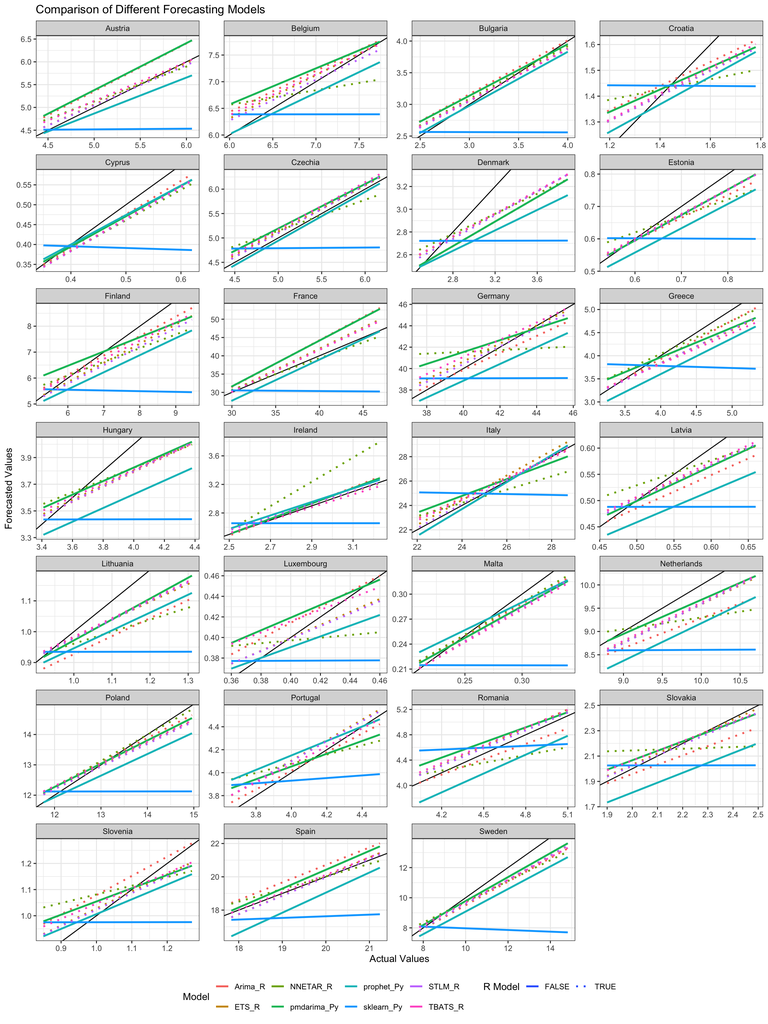

```r
pyResults <- reticulate::py$final_results # Access the Python object ### not sure why it stopped working

### if needed
pyResults <- read_csv("/Users/acas/Dropbox/BFF/projects/QuaterlyReports/Ember_API_python/multi_country_comparison.csv")

comp <- full_join(Rresults, pyResults, copy = TRUE) %>%
rename("Arima_R" ="AutoArima_R",   "sklearn_Py"="sklearn_arima",
       "prophet_Py"= "prophet" , "pmdarima_Py"="pmdarima")

# Overview per country
comp %>%
  pivot_longer(Arima_R:sklearn_Py) %>%
  ggplot(aes(x = Actual, y = value, color = name, linetype = grepl("_R$", name))) +
  geom_abline() +
  geom_smooth(method = 'lm', se = FALSE) +
  #geom_point() +
  facet_wrap(~Area, scales = 'free', ncol = 4) +
  theme_bw() +
  labs(title = "Comparison of Different Forecasting Models",
       x = "Actual Values",
       y = "Forecasted Values",
       color = "Model",
       linetype = "R Model") +
  scale_linetype_manual(values = c("solid", "dotted")) +
  theme(legend.position = "bottom")
```

## Comparing models using 2 metrics

- Mean Absolute Percentage Error (MAPE): Measures the average percentage difference between predicted and actual values. It’s scale-independent, making it useful for comparing forecasts across different datasets.
- Root Mean Square Error (RMSE): Measures the standard deviation of the residuals (prediction errors). It’s more sensitive to large errors and is in the same units as the response variable.
- If a model has low RMSE but high MAPE, it might be making large percentage errors on smaller values, while if a model has high RMSE but low MAPE, it might be making consistent percentage errors across all scales, but with some larger absolute errors.

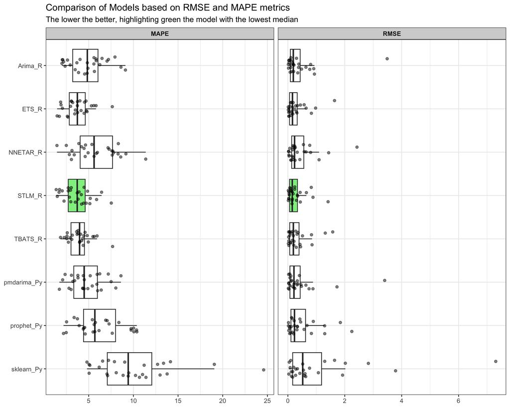

```r
models <- c("STLM_R", "TBATS_R", "NNETAR_R", "ETS_R", "Arima_R","sklearn_Py", "prophet_Py", "pmdarima_Py")

calculate_mape <- function(actual, predicted) {
  mean(abs((actual - predicted) / actual), na.rm = TRUE) * 100
}

# Function to calculate MAPE
calculate_mape <- function(actual, predicted) {
  mean(abs((actual - predicted) / actual), na.rm = TRUE) * 100
}

# Function to calculate RMSE
calculate_rmse <- function(actual, predicted) {
  sqrt(mean((actual - predicted)^2, na.rm = TRUE))
}

# Calculate metrics for each country
metrics_list <- comp %>%
  group_by(Area) %>%
  group_map(~ {
    mape_results <- sapply(models, function(model) {
      calculate_mape(.x$Actual, .x[[model]])
    })
    rmse_results <- sapply(models, function(model) {
      calculate_rmse(.x$Actual, .x[[model]])
    })
    data.frame(
      Area = .y$Area,
      Model = models,
      MAPE = mape_results,
      RMSE = rmse_results
    )
  })

# Combine results into a single dataframe
metrics_df <- do.call(rbind, metrics_list)

metrics_long <- metrics_df %>%
  pivot_longer(cols = c(RMSE, MAPE), names_to = "Metric", values_to = "Value")

metrics_long %>%
  group_by(Metric, Model) %>%
  summarise(Median = median(Value, na.rm = TRUE), .groups = "drop") %>%
  group_by(Metric) %>%
  mutate(Is_Lowest = Median == min(Median, na.rm = TRUE)) %>%
  ungroup() %>%
  right_join(metrics_long, by = c("Metric", "Model")) %>%
  ggplot(aes(x = fct_rev(fct_inorder(Model)),
             y = Value)) +
  geom_boxplot(aes(fill = Is_Lowest), outliers = FALSE) +
  geom_point(alpha = 0.5, position = position_jitter(width = 0.2, height = 0)) +
  facet_wrap(~ Metric, scales = "free_x", ncol = 2) +
  coord_flip() +
  scale_fill_manual(values = c("TRUE" = "lightgreen", "FALSE" = "white")) +
  theme_bw() +
  labs(title = "Comparison of Models based on RMSE and MAPE metrics",
       subtitle = "The lower the better, highlighting green the model with the lowest median",
       x = NULL,
       y = NULL) +
  theme(legend.position = 'none',
        strip.background = element_rect(fill = "lightgrey"),
        strip.text = element_text(face = "bold"))
```

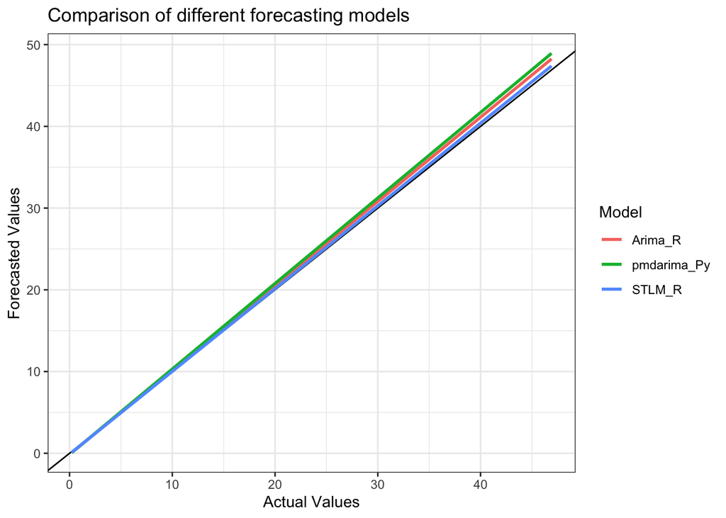

```r
comp %>%
  pivot_longer(c(Arima_R, STLM_R, pmdarima_Py)) %>%
  ggplot(aes(x = Actual, y = value, color = name)) +
  geom_abline() +
  geom_smooth(method = 'lm', se = FALSE) +
  #geom_point() +
  #facet_wrap(~Area, scales = 'free') +
  theme_bw() +
  labs(title = "Comparison of different forecasting models",
       x = "Actual Values",
       y = "Forecasted Values",
       color = "Model",
       linetype = "R Model")
```